# Project 1-Multivariate Methods

Vincent Locke

3/19/2018

We need to set the directory and load the packages we will need.

This function was obtained from github https://github.com/ChrKoenig/R_marginal_plot/blob/master/marginal_plot.R

Load Bank Dataset

Create a marginal plot comparing sales vs profits

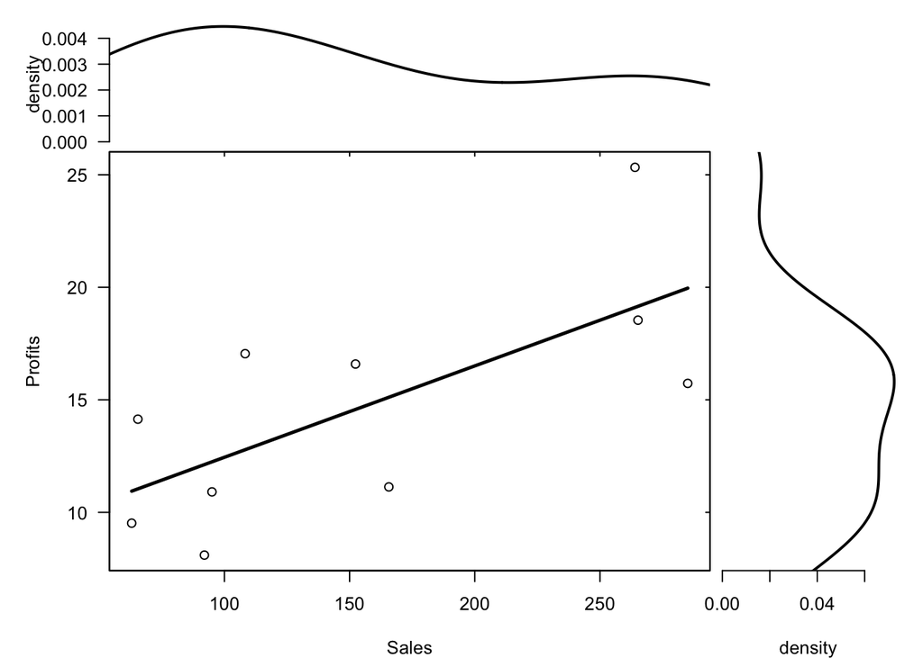

This plot shows that there is positive correlation between Sales and Profits with somewhat of a linear relationship, but it can also be said that due to the small sample size this could be misleading.

Create a second marginal plot comparing profits vs assets

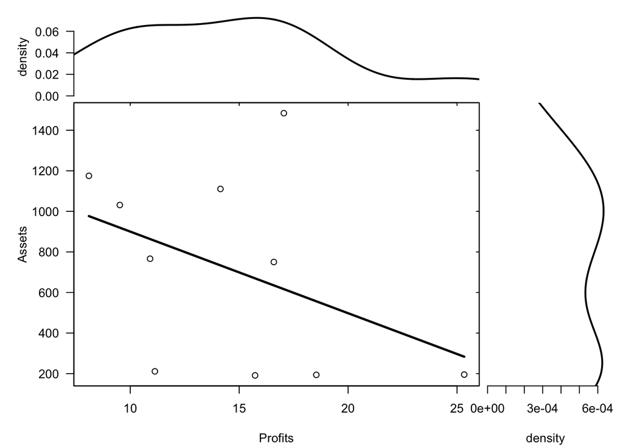

In this second marginal plot, we can actually see negative correlation between Profits and Assets.

Create a third marginal plot comparing sales vs assets

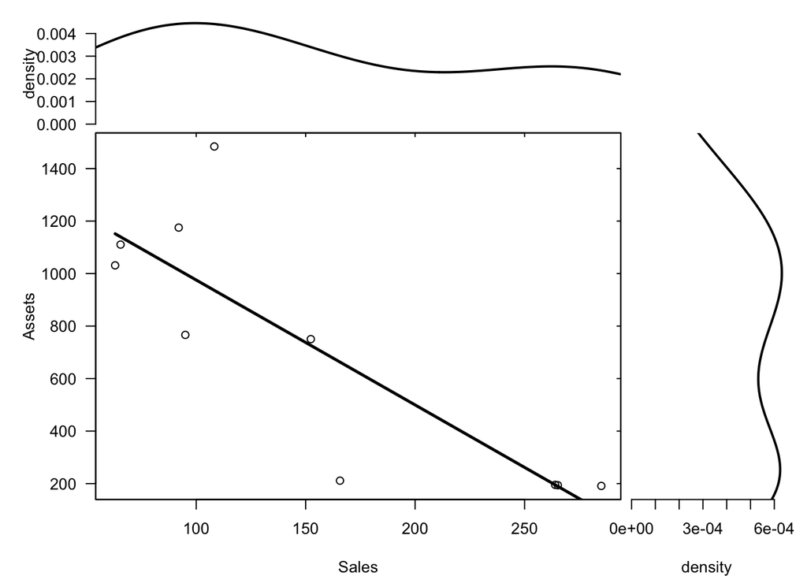

In this third marginal plot, similar to the second plot we see negative correlation between Sales and Assets as well.

Load the Radiotherapy Dataset

Create a marginal plot comparing the amount of activity vs amount of sleep

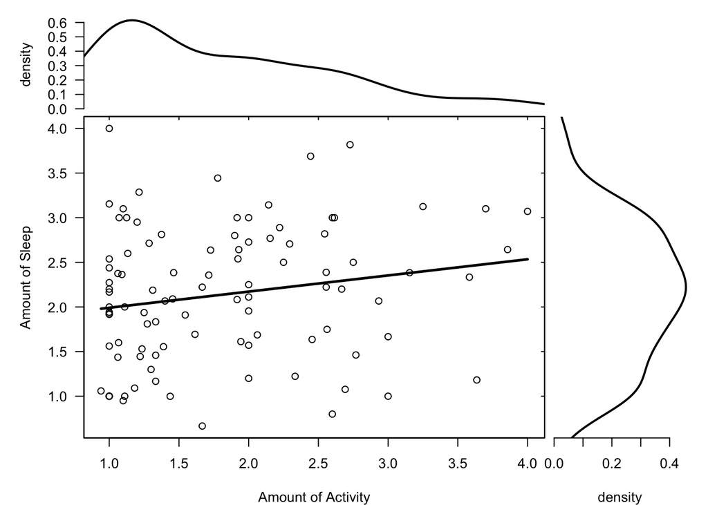

In this marginal plot, there is positive correlation between the amount of activity and the amount of sleep, but we can also see the presence of possible outliers that are shown in the top left corner.

Load the National Track Records for Women Dataset

Summary of Track Data

```
##     Country        s100            s200            s400
##  ARG    : 1   Min.   :10.49   Min.   :21.34   Min.   :47.60
##  AUS    : 1   1st Qu.:11.12   1st Qu.:22.57   1st Qu.:49.97
##  AUT    : 1   Median :11.32   Median :22.98   Median :51.65
##  BEL    : 1   Mean   :11.36   Mean   :23.12   Mean   :51.99
##  BER    : 1   3rd Qu.:11.57   3rd Qu.:23.61   3rd Qu.:53.12
##  BRA    : 1   Max.   :12.52   Max.   :25.91   Max.   :61.65
##  (Other):48
##       m800           m1500           m3000           Marathon
##  Min.   :1.890   Min.   :3.840   Min.   : 8.100   Min.   :135.2
##  1st Qu.:1.970   1st Qu.:4.003   1st Qu.: 8.543   1st Qu.:143.5
##  Median :2.005   Median :4.100   Median : 8.845   Median :148.4
##  Mean   :2.022   Mean   :4.189   Mean   : 9.081   Mean   :153.6
##  3rd Qu.:2.070   3rd Qu.:4.338   3rd Qu.: 9.325   3rd Qu.:157.7
##  Max.   :2.290   Max.   :5.420   Max.   :13.120   Max.   :221.1
##
```

Lets convert the country variable to character format and use this as our row name.

Mean of the variables

```
##       s100       s200       s400       m800      m1500      m3000
##  11.357778  23.118519  51.989074   2.022407   4.189444   9.080741
##   Marathon
## 153.619259
```

Variance of the variables

```
##                s100       s200       s400        m800      m1500
## s100     0.15531572  0.3445608  0.8912960 0.027703564 0.08389119
## s200     0.34456080  0.8630883  2.1928363 0.066165898 0.20276331
## s400     0.89129602  2.1928363  6.7454576 0.181807932 0.50917683
## m800     0.02770356  0.0661659  0.1818079 0.007546925 0.02141457
## m1500    0.08389119  0.2027633  0.5091768 0.021414570 0.07418270
## m3000    0.23388281  0.5543502  1.4268158 0.061379315 0.21615514
## Marathon 4.33417757 10.3849876 28.9037314 1.219654647 3.53983732
##                m3000   Marathon
## s100      0.23388281   4.334178
## s200      0.55435017  10.384988
## s400      1.42681579  28.903731
## m800      0.06137932   1.219655
## m1500     0.21615514   3.539837
## m3000     0.66475793  10.706091
## Marathon 10.70609113 270.270150
```

Correlation of the variables

```
##               s100      s200      s400      m800     m1500     m3000
## s100     1.0000000 0.9410886 0.8707802 0.8091758 0.7815510 0.7278784
## s200     0.9410886 1.0000000 0.9088096 0.8198258 0.8013282 0.7318546
## s400     0.8707802 0.9088096 1.0000000 0.8057904 0.7197996 0.6737991
## m800     0.8091758 0.8198258 0.8057904 1.0000000 0.9050509 0.8665732
## m1500    0.7815510 0.8013282 0.7197996 0.9050509 1.0000000 0.9733801
## m3000    0.7278784 0.7318546 0.6737991 0.8665732 0.9733801 1.0000000
## Marathon 0.6689597 0.6799537 0.6769384 0.8539900 0.7905565 0.7987302
##           Marathon
## s100     0.6689597
## s200     0.6799537
## s400     0.6769384
## m800     0.8539900
## m1500    0.7905565
## m3000    0.7987302
## Marathon 1.0000000
```

The results show that there is positive correlation between the groups with the largest coming from races that are similar.

Lets convert the distance from Meters to Meters Per Second

Mean of the variables

```
##     s100     s200     s400     m800    m1500    m3000 Marathon
## 8.814772 8.664408 7.712067 6.604214 5.989687 5.542701 4.620264
```

Variance of the variables

```
##                s100       s200       s400       m800      m1500      m3000
## s100     0.09053826 0.09560635 0.09667244 0.06506402 0.08221980 0.09214221
## s200     0.09560635 0.11467144 0.11386990 0.07492487 0.09601895 0.10543645
## s400     0.09667244 0.11386990 0.13778886 0.08094090 0.09544299 0.10831645
## m800     0.06506402 0.07492487 0.08094090 0.07352284 0.08645423 0.09975466
## m1500    0.08221980 0.09601895 0.09544299 0.08645423 0.12384050 0.14371481
## m3000    0.09214221 0.10543645 0.10831645 0.09975466 0.14371481 0.17658433
## Marathon 0.08109987 0.09331033 0.10188073 0.09430563 0.11845777 0.14656043
##            Marathon
## s100     0.08109987
## s200     0.09331033
## s400     0.10188073
## m800     0.09430563
## m1500    0.11845777
## m3000    0.14656043
## Marathon 0.16671409
```

Correlation of the variables

```
##               s100      s200      s400      m800     m1500     m3000
## s100     1.0000000 0.9383028 0.8655248 0.7974687 0.7764777 0.7287297
## s200     0.9383028 1.0000000 0.9058875 0.8159945 0.8057456 0.7409469
## s400     0.8655248 0.9058875 1.0000000 0.8041737 0.7306437 0.6944025
## m800     0.7974687 0.8159945 0.8041737 1.0000000 0.9060324 0.8754795
## m1500    0.7764777 0.8057456 0.7306437 0.9060324 1.0000000 0.9718385
## m3000    0.7287297 0.7409469 0.6944025 0.8754795 0.9718385 1.0000000
## Marathon 0.6601124 0.6748635 0.6722005 0.8518052 0.8244153 0.8541900
##           Marathon
## s100     0.6601124
## s200     0.6748635
## s400     0.6722005
## m800     0.8518052
## m1500    0.8244153
## m3000    0.8541900
## Marathon 1.0000000
```

The results are similar to our initial review of the mean, variance, and correlation. There’s positive correlation between the groups with emphasis on the races with similar distances.

Load the Bankruptcy Dataset

Lets create a 3D scatter plot comparing bankruptcy vs nonbankruptcy banks

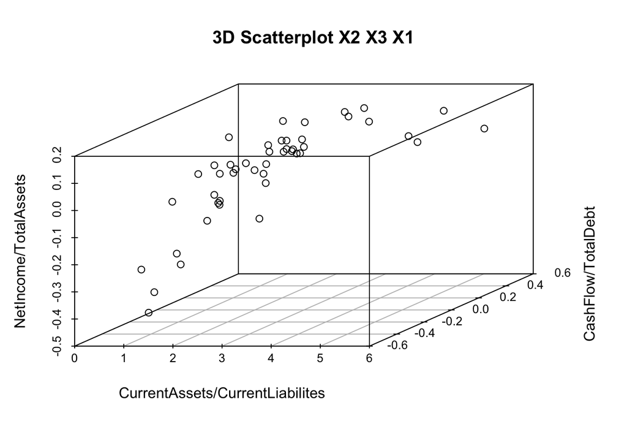

The 3D scatter plot suggests there could be some outliers towards the top right and the plot also looks like a cigar but bent towards the top, which is a good sign.

Now lets rearrange the Bankruptcy Dataset and change the d variable to numeric and the e variable to a factor

Lets create a second 3D scatter plot showing bankruptcy and nonbankruptcy

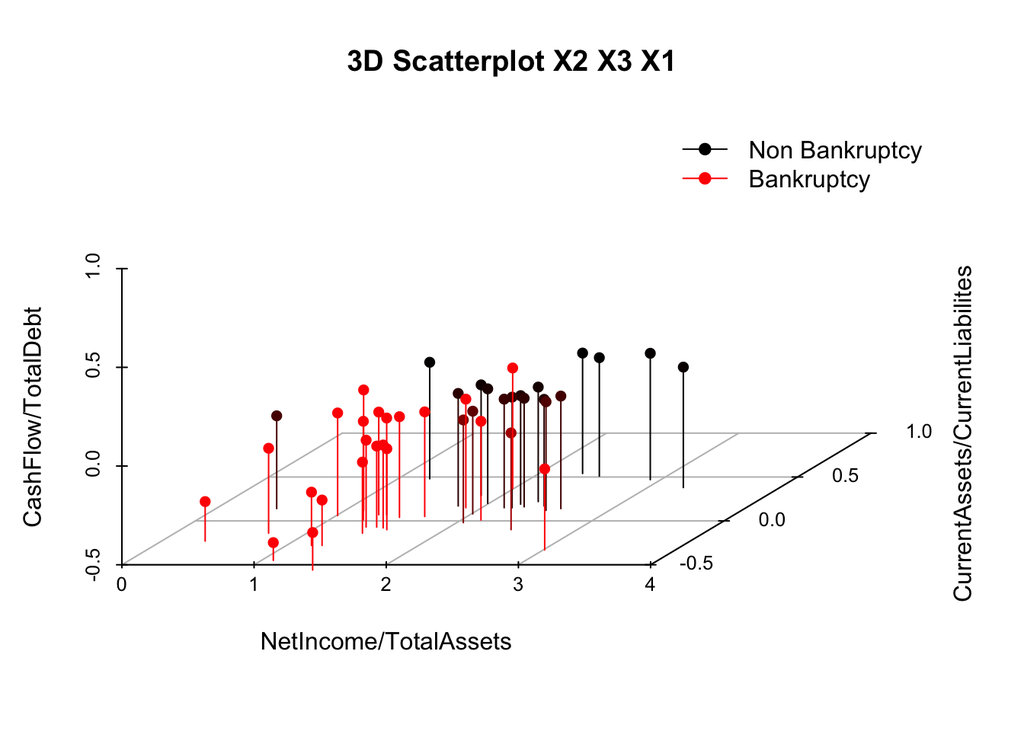

The 3d scatter plot shows that there probably is an outlier for a bankrupted bank that shows up in the non-bankrupted banks.

Load the Public Utility Company Dataset

Lets create a star chart

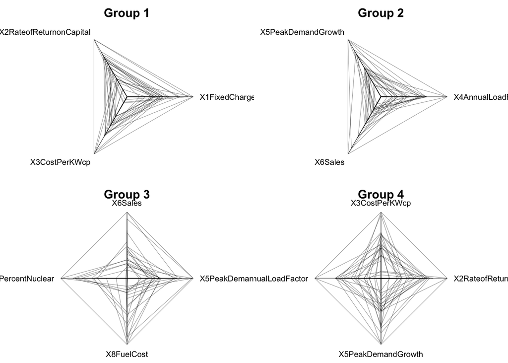

Load the National Park Dataset Dataset

We need to create a new variable that will represent the parks

National Parks Arcadia 1 Bruce Canyon 2 Cuyahoga Valley 3 Everglades 4 Grand Canyon 5 Grand Teton 6 Great Smokey 7 Hot Springs 8 Olympic 9 Mount Rainier 10 Rocky Mountain 11 Shenandoah 12 Yellowstone 13 Yosemite 14 Zion 15

Create a scatter plot comparing size vs visitors

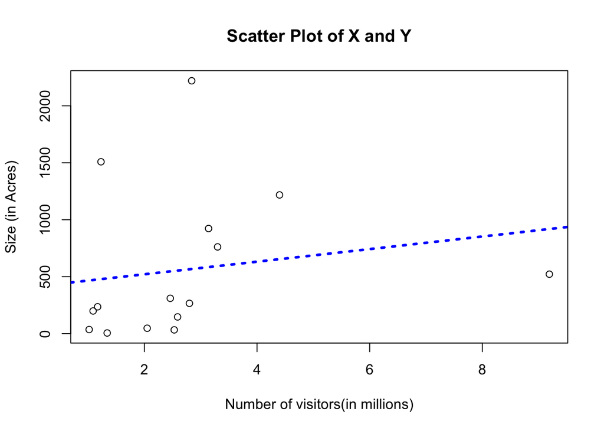

If we take a look at the plot, we can clearly see that there is an outlier that is effecting model.

To figure our which park is the outlier, lets take a look at the data.

```
##      Size Visitors Park
## 1    47.4     2.05    1
## 2    35.8     1.02    2
## 3    32.9     2.53    3
## 4  1508.5     1.23    4
## 5  1217.4     4.40    5
## 6   310.0     2.46    6
## 7   521.8     9.19    7
## 8     5.6     1.34    8
## 9   922.7     3.14    9
## 10  235.6     1.17   10
## 11  265.8     2.80   11
## 12  199.0     1.09   12
## 13 2219.8     2.84   13
## 14  761.3     3.30   14
## 15  146.6     2.59   15
```

Comparing the dataset to the scatter plot, we see that park 7 or The Great Smokey National Park is the outlier.

Before we do anything, lets check the correlation between Visitors and Size.

```
## [1] 0.1725274
```

It comes out at 0.1725274, which isnt the bet. So lets remove The Great Smokey National Park and plot the data and rerun the cor() to see if it improves correlation between the two.

First remove The Great Smokey National Park from the data.

Now lets re-plot the scatter plot

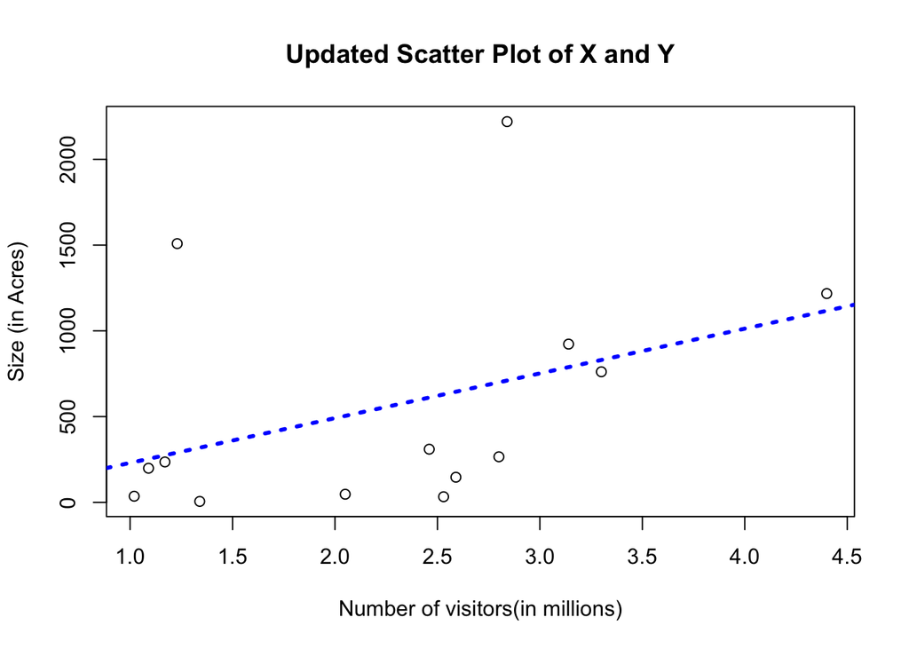

It definitly improves the scatter plot so now lets also check correlation between the two again.

```
## [1] 0.3907829
```

The correlation coefficient is 0.3907829, which is definitly an improvement.